# Práctica guiada: Regresión lineal (OLS)

Basado en *Econometrics with R* (Sección 4.2)

# 1 Objetivos de aprendizaje

Al finalizar esta práctica podrá:

1. Repasar modelos de **regresión lineal simple** con una variable explicativa **cualitativa (dummy / factor)**.
2. Interpretar regresiones con **transformación logarítmica**.
3. Estimar e interpretar un modelo de **regresión lineal múltiple** con transformaciones y variables explicativas cuantitativas y cualitativas.

# 2 Preparación

## 2.1 Paquetes

```r
# Si no los tienes instalados, ejecuta una vez:
# install.packages(c("AER","ggplot2","dplyr","lmtest","sandwich"))

library(AER)       # Datos (CASchools, CPSSWEducation)
library(ggplot2)   # Gráficos
library(dplyr)     # Manipulación de datos
library(lmtest)    # coeftest()
library(sandwich)  # vcovHC()
```

# 3 Regresion 1: Repaso de regresiones con X cualitativa (dummy / factor) con CPSSWEducation

## 3.1 Cargar datos y revisar la variable categórica

```r
data("CPSSWEducation")

class(CPSSWEducation$gender)
```

```
[1] "factor"
```

```r
levels(CPSSWEducation$gender)
```

```
[1] "female" "male"
```

## 3.2 Visualización: boxplot por género

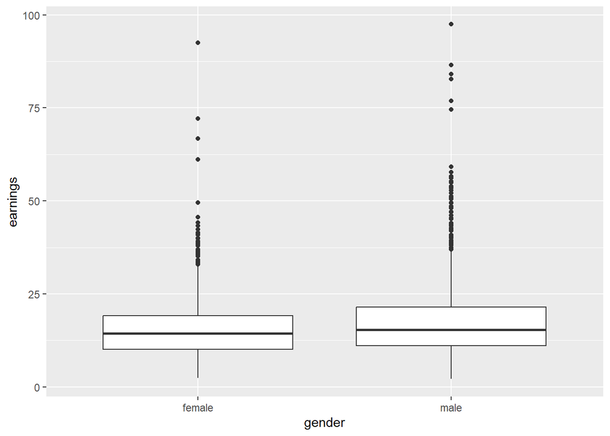

```r
ggplot(CPSSWEducation, aes(x = gender, y = earnings)) +
  geom_boxplot()
```

**Qué mirar**: - Diferencia en medianas / medias - Dispersión por grupo - Asimetría y valores extremos

## 3.3 Crear una dummy manual (opcional) y conectarla con t-test

Creamos `Dummy = 1` si es hombre, `0` si es mujer.

```r
CPSSWEducation <- CPSSWEducation %>%
  mutate(Dummy = ifelse(gender == "male", 1, 0))
```

Gráfico “tipo regresión” con Dummy:

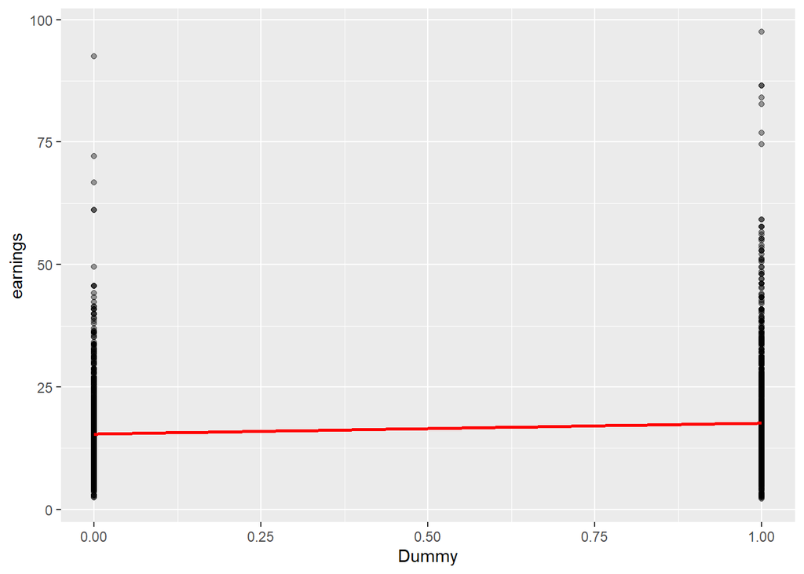

```r
ggplot(CPSSWEducation, aes(x = Dummy, y = earnings)) +
  geom_point(alpha = 0.4) +
  geom_smooth(method = lm, se = FALSE, color = "red")
```

## 3.4 Modelo con dummy

```r
modelo2_dummy <- lm(earnings ~ Dummy, data = CPSSWEducation)
summary(modelo2_dummy)
```

```
Call:
lm(formula = earnings ~ Dummy, data = CPSSWEducation)

Residuals:
    Min      1Q  Median      3Q     Max
-15.513  -6.001  -1.916   3.792  79.850

Coefficients:
            Estimate Std. Error t value Pr(>|t|)
(Intercept)  15.4232     0.2694  57.252  < 2e-16 ***
Dummy         2.2268     0.3500   6.363 2.29e-10 ***
---
Signif. codes:  0 '***' 0.001 '**' 0.01 '*' 0.05 '.' 0.1 ' ' 1

Residual standard error: 9.34 on 2948 degrees of freedom
Multiple R-squared:  0.01355,   Adjusted R-squared:  0.01321
F-statistic: 40.49 on 1 and 2948 DF,  p-value: 2.286e-10
```

**Interpretación clave**: - Intercepto: media esperada de ingresos cuando Dummy = 0 (mujeres). - Coeficiente de Dummy: diferencia promedio (hombres − mujeres).

## 3.5 El mismo modelo usando el factor `gender`

```r
modelo2_factor <- lm(earnings ~ gender, data = CPSSWEducation)
summary(modelo2_factor)
```

```
Call:
lm(formula = earnings ~ gender, data = CPSSWEducation)

Residuals:
    Min      1Q  Median      3Q     Max
-15.513  -6.001  -1.916   3.792  79.850

Coefficients:
            Estimate Std. Error t value Pr(>|t|)
(Intercept)  15.4232     0.2694  57.252  < 2e-16 ***
gendermale    2.2268     0.3500   6.363 2.29e-10 ***
---
Signif. codes:  0 '***' 0.001 '**' 0.01 '*' 0.05 '.' 0.1 ' ' 1

Residual standard error: 9.34 on 2948 degrees of freedom
Multiple R-squared:  0.01355,   Adjusted R-squared:  0.01321
F-statistic: 40.49 on 1 and 2948 DF,  p-value: 2.286e-10
```

```r
aggregate(earnings ~ gender, data = CPSSWEducation, mean)
```

```
  gender earnings
1 female 15.42323
2   male 17.65006
```

```r
confint(modelo2_factor)
```

```
               2.5 %    97.5 %
(Intercept) 14.89501 15.951441
gendermale   1.54063  2.913027
```

**Comentario:** con un factor de 2 niveles, el coeficiente del segundo nivel es exactamente la diferencia de medias respecto a la categoría base.

# 4 Regresion 2: Regresión simple (X cuantitativa) con CASchools

## 4.1 Cargar datos y construir la variable X

- **Idea**: queremos explicar el puntaje promedio de matemáticas (`math`) usando el ratio de estudiantes por profesor (`estxprof`). El ratio se calcula como `students/teachers`.

```r
data("CASchools")


# Construimos el ratio de estudiantes por profesor
CASchools$estxprof <- CASchools$students / CASchools$teachers
```

**Interpretación esperada de X**: - Si `estxprof` aumenta, hay (en promedio) más estudiantes por profesor.  
- La pregunta es si eso se asocia a mejores o peores puntajes en matemáticas.

## 4.2 Exploración gráfica (nube de puntos + recta OLS)

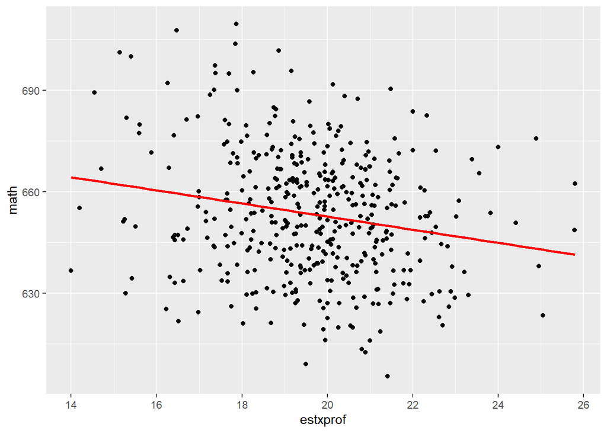

```r
ggplot(CASchools, aes(x = estxprof, y = math)) +
  geom_point() +
  geom_smooth(method = lm, se = FALSE, color = "red")
```

**Qué mirar en el gráfico**: - ¿Parece haber tendencia negativa o positiva? - ¿La relación parece aproximadamente lineal? - ¿Hay puntos extremos (outliers) fuertes?

## 4.3 Descriptivos básicos

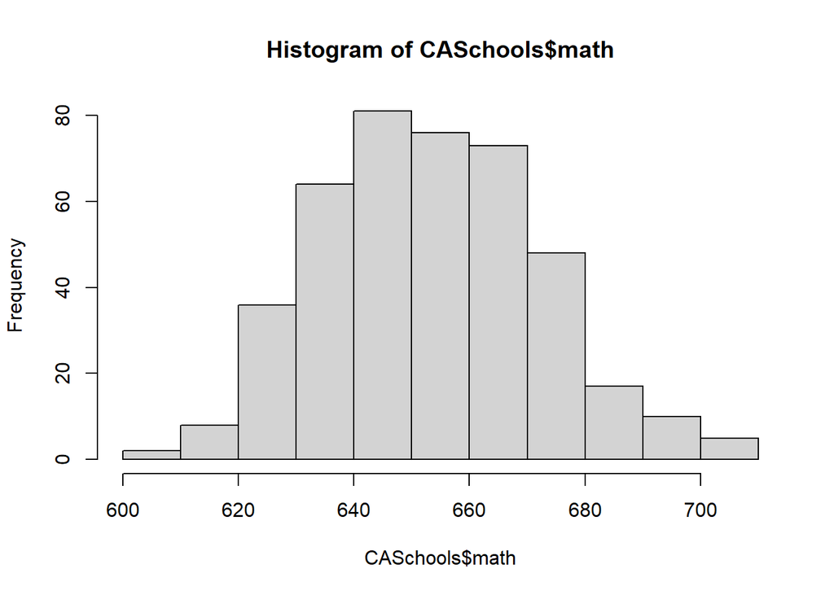

```r
hist(CASchools$math)
```

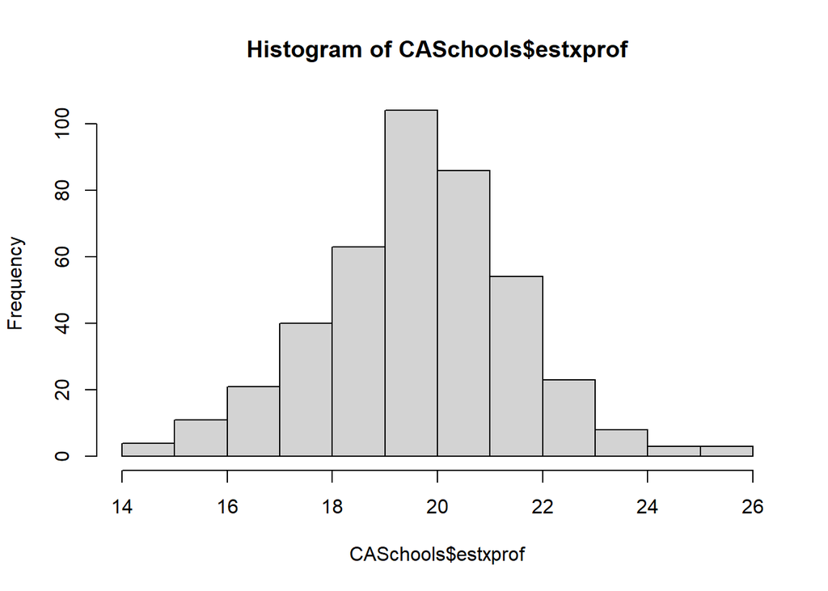

```r
hist(CASchools$estxprof)
```

```r
mean(CASchools$math); sd(CASchools$math)
```

```
[1] 653.3426
```

```
[1] 18.7542
```

```r
mean(CASchools$estxprof); sd(CASchools$estxprof)
```

```
[1] 19.64043
```

```
[1] 1.891812
```

**Comentario:** Es importante iniciar analizando de forma descriptiva las variables de interés (tanto cualitativas como cuantitativas). Esto ayuda a comprender mejor el tipo de información con la que vamos a trabajar el OLS y los resultados que obtendremos.

## 4.4 Estimar el modelo y leer los coeficientes

Modelo:
$$math_i = \beta_0 + \beta_1 estxprof_i + u_i$$

```r
modelo1 <- lm(math ~ estxprof, data = CASchools)
summary(modelo1)
```

```
Call:
lm(formula = math ~ estxprof, data = CASchools)

Residuals:
    Min      1Q  Median      3Q     Max
-44.615 -13.374  -0.828  12.728  52.711

Coefficients:
            Estimate Std. Error t value Pr(>|t|)
(Intercept) 691.4174     9.3825  73.692  < 2e-16 ***
estxprof     -1.9386     0.4755  -4.077 5.47e-05 ***
---
Signif. codes:  0 '***' 0.001 '**' 0.01 '*' 0.05 '.' 0.1 ' ' 1

Residual standard error: 18.41 on 418 degrees of freedom
Multiple R-squared:  0.03824,   Adjusted R-squared:  0.03594
F-statistic: 16.62 on 1 and 418 DF,  p-value: 5.467e-05
```

### 4.4.1 Cómo interpretar

- **Intercepto** $\beta_0$: valor esperado de `math` cuando `estxprof = 0`.  
  (No siempre tiene interpretación realista; es un punto de referencia del modelo.)
- **Pendiente** $\beta_1$: cambio esperado en `math` ante **un aumento de 1 unidad** en `estxprof` (es decir, 1 estudiante adicional por profesor, en promedio), manteniendo lo demás constante.

**Pregunta:** ¿el signo de $\beta_1$ concuerda con el gráfico?

## 4.5 Predicción (valores ajustados)

```r
CASchools$math_hat  <- predict(modelo1)
CASchools$math_hat1 <- modelo1$fitted.values
head(CASchools[, c("math","estxprof","math_hat")])
```

```
   math estxprof math_hat
1 690.0 17.88991 656.7362
2 661.9 21.52466 649.6899
3 650.9 18.69723 655.1711
4 643.5 17.35714 657.7690
5 639.9 18.67133 655.2213
6 605.4 21.40625 649.9194
```

**Idea**: el valor ajustado es $\hat{y}_i$, la mejor predicción lineal de `math` dada `estxprof`.

# 5 Regresion 3: Regresión simple (X cuantitativa) — earnings ~ education

## 5.1 Visualización

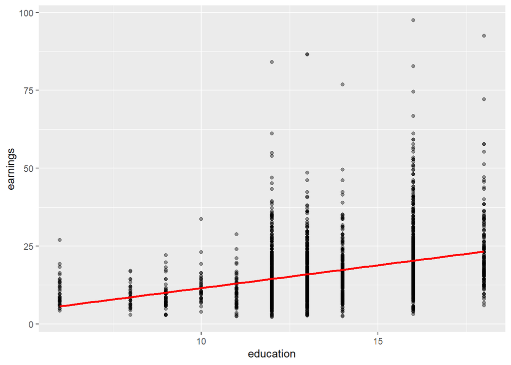

```r
ggplot(CPSSWEducation, aes(x = education, y = earnings)) +
  geom_point(alpha = 0.4) +
  geom_smooth(method = lm, se = FALSE, color = "red")
```

## 5.2 Estimar y leer el modelo

```r
modelo3 <- lm(earnings ~ education, data = CPSSWEducation)
summary(modelo3)
```

```
Call:
lm(formula = earnings ~ education, data = CPSSWEducation)

Residuals:
    Min      1Q  Median      3Q     Max
-17.270  -5.355  -1.513   3.194  77.164

Coefficients:
            Estimate Std. Error t value Pr(>|t|)
(Intercept) -3.13437    0.95925  -3.268   0.0011 **
education    1.46693    0.06978  21.021   <2e-16 ***
---
Signif. codes:  0 '***' 0.001 '**' 0.01 '*' 0.05 '.' 0.1 ' ' 1

Residual standard error: 8.769 on 2948 degrees of freedom
Multiple R-squared:  0.1304,    Adjusted R-squared:  0.1301
F-statistic: 441.9 on 1 and 2948 DF,  p-value: < 2.2e-16
```

**Interpretación típica**: - $\beta_1$: cambio promedio en `earnings` por **un año adicional** de educación (si `education` está en años).

**Pregunta:** ¿parece posible que el efecto sea constante para todo nivel educativo?.

# 6 Regresion 4: Transformación logarítmica y regresión múltiple

## 6.1 ¿Por qué transformar?

Los ingresos suelen ser: - positivos, - asimétricos (cola a la derecha), - con algunos valores muy altos.

Esto hace útil usar log(ingreso) para: - reducir asimetría, - interpretar efectos como cambios porcentuales (aprox.).

## 6.2 Crear log(earnings)

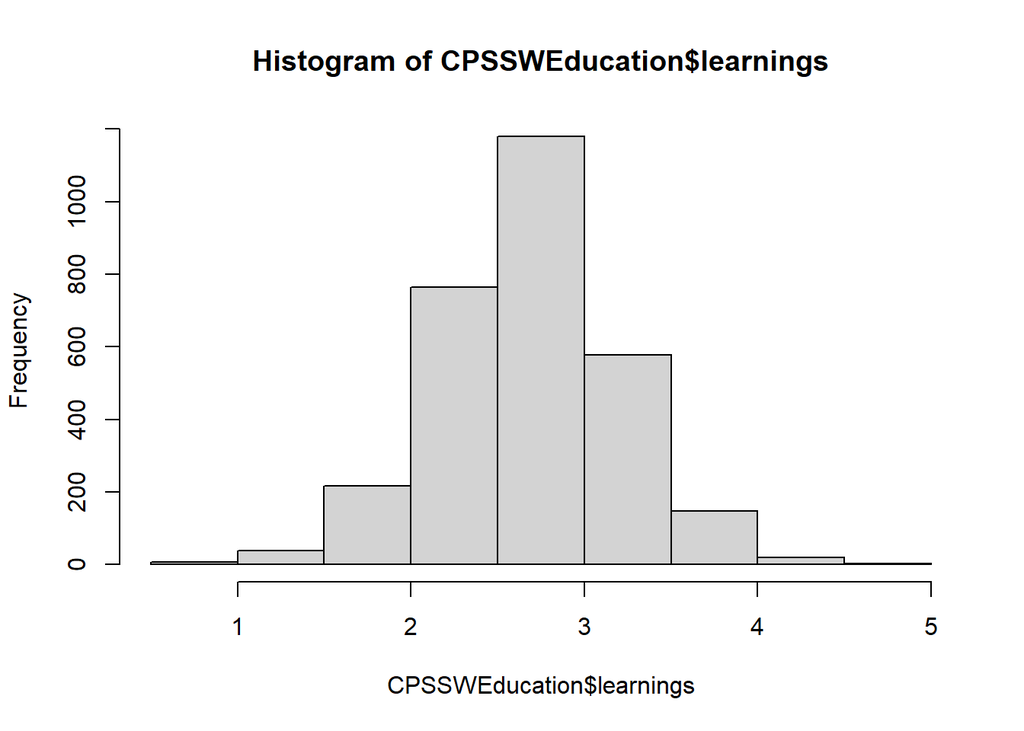

```r
CPSSWEducation$learnings <- log(CPSSWEducation$earnings)

hist(CPSSWEducation$learnings)
```

### 6.2.1 Modelo en logaritmos ambos lados (log-log)

Si el modelo es:
$$\log(y)=\beta_0+\beta_1 log(X) + \dots$$

```r
modelo4 <- lm(learnings ~ log(education), data = CPSSWEducation)
summary(modelo4)
```

```
Call:
lm(formula = learnings ~ log(education), data = CPSSWEducation)

Residuals:
     Min       1Q   Median       3Q      Max
-1.86213 -0.28776  0.00587  0.29121  1.85921

Coefficients:
               Estimate Std. Error t value Pr(>|t|)
(Intercept)     -0.1025     0.1215  -0.843    0.399
log(education)   1.0768     0.0468  23.007   <2e-16 ***
---
Signif. codes:  0 '***' 0.001 '**' 0.01 '*' 0.05 '.' 0.1 ' ' 1

Residual standard error: 0.4727 on 2948 degrees of freedom
Multiple R-squared:  0.1522,    Adjusted R-squared:  0.1519
F-statistic: 529.3 on 1 and 2948 DF,  p-value: < 2.2e-16
```

**Interpretación**: un aumento de 1% en $X$ produce un cambio de ($\beta_1$)% en $Y$.

### 6.2.2 Relaciones semilogaritmicas (Log - Lineal)

Si el modelo es:
$$\log(y)=\beta_0+\beta_1 X + \dots$$

```r
modelo5 <- lm(learnings ~ gender, data = CPSSWEducation)
summary(modelo5)
```

```
Call:
lm(formula = learnings ~ gender, data = CPSSWEducation)

Residuals:
     Min       1Q   Median       3Q      Max
-1.97533 -0.32051  0.00883  0.33073  1.91028

Coefficients:
            Estimate Std. Error t value Pr(>|t|)
(Intercept)  2.61693    0.01471 177.867  < 2e-16 ***
gendermale   0.11768    0.01911   6.157 8.41e-10 ***
---
Signif. codes:  0 '***' 0.001 '**' 0.01 '*' 0.05 '.' 0.1 ' ' 1

Residual standard error: 0.5101 on 2948 degrees of freedom
Multiple R-squared:  0.0127,    Adjusted R-squared:  0.01236
F-statistic: 37.91 on 1 and 2948 DF,  p-value: 8.412e-10
```

**Interpretación**: Un aumento de una unidad en $X$ provoca un cambio de ($\beta_1$)*100% en $Y$, cuando es pequeño.

Ejemplo: - si ($\beta_1 = 0.05$), entonces ≈ **5%**.

Si $\beta_1$ es grande (mayor a 0.1) el cambio que provoca es ($e^{\beta_1}-1$)*100% en Y

**Finalmente, una última relación podría ser: Lineal - Log, donde un aumento de un 1% en $X$ provoca un cambio de $\beta_1$/100 unidades en $Y$**

## 6.3 Modelo múltiple que incluye transformaciones

```r
modelo6 <- lm(learnings ~ log(education)+gender+age, data = CPSSWEducation)
summary(modelo6)
```

```
Call:
lm(formula = learnings ~ log(education) + gender + age, data = CPSSWEducation)

Residuals:
     Min       1Q   Median       3Q      Max
-1.89537 -0.28073  0.01666  0.28813  1.80573

Coefficients:
               Estimate Std. Error t value Pr(>|t|)
(Intercept)    -1.23160    0.51922  -2.372   0.0178 *
log(education)  1.15185    0.04650  24.772   <2e-16 ***
gendermale      0.18482    0.01760  10.503   <2e-16 ***
age             0.02797    0.01709   1.637   0.1017
---
Signif. codes:  0 '***' 0.001 '**' 0.01 '*' 0.05 '.' 0.1 ' ' 1

Residual standard error: 0.464 on 2946 degrees of freedom
Multiple R-squared:  0.1835,    Adjusted R-squared:  0.1826
F-statistic: 220.6 on 3 and 2946 DF,  p-value: < 2.2e-16
```

# 7 Cierre: checklist de lo que debe poder explicar

1. ¿Qué representa el intercepto y la pendiente en OLS?
2. ¿Qué significa “controlar por” variables?
3. ¿Qué significa una dummy y su coeficiente?
4. ¿Por qué log(ingresos) cambia la interpretación del modelo?
5. ¿Por qué es mala idea reportar solo p-valores sin magnitud?

# 8 Referencia

Los datos y ejercicios se inspiran en el libro en línea *Econometrics with R*, sección “Estimating the coefficients of the linear regression model (4.2)”.